# Class project: UFO Sightings in the United States

## 1. Introduction

**A. Question**

My project focuses on UFO sightings in the United States. I am looking at data made public by the Intelligence Authorization Act collected by the Office of Naval Intelligence through the Unidentified Aerial Phenomenon Task Force project. A few questions I have are in regards to the location of these sightings and whether they coincide with the location of military bases. I grew up between a Marine Corps Logistics Base and Fort Irwin so I would spend a lot of time outside with my grandparents watching the sky for shooting stars, the ISS, satellites, and UFOs. I would like to know if it is more common for there to be UFO sightings in areas near military bases or if this just happened to be a random, niche interest of my family. I am planning on running a hypothesis test to know whether there is a statistically significant relationship between UFO sightings and proximity to military bases in the United States.

**B. Importance**

The reason it is important to look at UFO sightings is because they could possibly be advanced foreign aviation technology. The idea of otherworldly life is exciting, but more than likely, the UFOs we see are just advanced technologies from other countries that we haven't seen before. It is important to track these sightings to find trends in the data that could help strengthen airspace security and answer the public;s questions about UFOs. It is important to note that even if there is some type of correlation between UFO sightings and military bases, there may be other factors to these UFO sightings that I may not have taken into consideration.

**C. Data**

I got my data from: http://www.uforesearchdb.com/

The website I downloaded the csv file from: https://www.kaggle.com/datasets/salmanfaroz/ufo-sightings-in-the-us?resource=download

There are 3437 UFO sightings in the data file. Each sighting includes: Date, Shape, Location, State, Country, and Source.

I am also using another dataset from Kaggle named US Military Bases that contains the geolocation of 776 bases: https://www.kaggle.com/datasets/mexwell/us-military-bases

**D. Other Analyses**

I looked into the data from the database and I see that the database website already put data into categories. For instance, for every UFO shape, there is a histogram with the count of that shape in each state. I think the histograms are a poor way to represent this data so my goal is to use spatial mapping for clearer visualization. I also googled my question regarding whether UFO sightings are more common in areas with military bases and although all articles pointed to a correlation, none of them used any actual data or data mapping to prove this relationship. I also found CNN and VICE articles less than a week old all talking about the rise of UFO sightings and data gathered by the military. This correlation is therefore relevant to today and in need of actual statistical data to either prove or disprove all of these statements in the media.

```python
import pandas as pd
import geopandas as gpd
import warnings
import YData
import matplotlib.pyplot as plt
import numpy as np

ufo_sightings = pd.read_csv("ufo_location.csv")

military_bases = pd.read_csv("military-bases-clean.csv", quotechar = '"', on_bad_lines = 'skip')
#added this to make sure data for bases would work properly
```

## 2. Visualizations of the data

### Data Wrangling

The data for my project required a lot of data wrangling. I will separate the two data sets and talk about each one below. All of the data wrangling I did was on the actual csv file through pages. I also wanted to mention that for the actual code I have labeled some parts to make it easier to understand why I did what I did.

#### UFO Data

For the UFO data, first I decided that I only wanted to work on the United States. I deleted all data points in Canada, India, etc. Next, I wanted to be able to plot my data so I used ChatGPT to feed it cities and then I would paste in the coordinates into latitudes and longitudes. This took a very long time, over 5 hours. I wish I knew an easier way but the amount of data I had wouldn't allow me to run all of it at once. I also removed data points that were not specific enough to find a gps coordinate.

#### Military Base Data

For the military base location data, I deleted any data that was not a part of the United States. I also decided I would not be including Guam or Puerto Rico. I did this so that the data would match up with the same map I have for the UFO sightings. I also deleted some data that was already part of the csv. I think the way it was formatted was not right for Python so I kept the coordinates only and separated them into Latitude and Longitude later on when I mapped the data.

### UFO Data

The UFO Data is the major focus of my project, but I decided to move data exploration through graphs to the Appendix because it took up too much space and doesn't add as much as my other graphs do.

```python
ufo_sightings.columns
```

```
Index(['Event.Date', 'Shape', 'Location', 'State', 'Country', 'Source',
       'Latitude', 'Longitude'],
      dtype='object')
```

### Military Data

There is not much I feel I can show about the military base data that I feel would add more than my GeoPandas Map. I did however want to mention that I had a random point for Alaska that was not fitting my mapping of The United States, so I decided to just not include that point by shrinking the longitude and latitude parameters.

```python
military_bases.columns
```

```
Index(['Geo Point', 'OBJECTID_1', 'OBJECTID', 'COMPONENT', 'Site Name',
       'State Terr', 'COUNTRY', 'Oper Stat', 'PERIMETER', 'AREA', 'Shape_Leng',
       'Shape_Area'],
      dtype='object')
```

### Combining Data through Geopandas

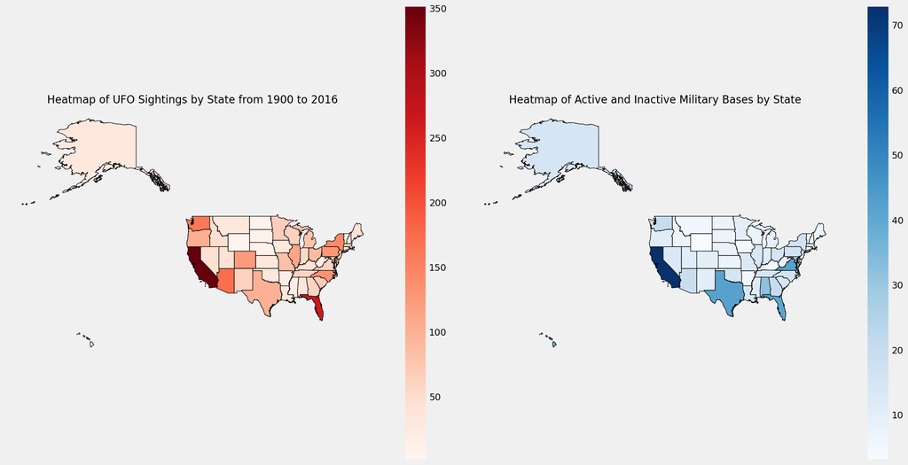

```python
state_map = gpd.read_file("States_shapefile.geojson")

# just in case data gets ruined
ufo_sightings_copy = ufo_sightings.copy()

# making sure state columns are the same in both groups of data
sightings_per_state = ufo_sightings_copy.groupby("State").size().reset_index(name = "Sightings")
sightings_per_state["State"] = sightings_per_state["State"].str.strip()

sate_ufo_sightings = state_map.merge(sightings_per_state, left_on = "State_Code", right_on = "State", how = "left")

fig, ax = plt.subplots(1, 2, figsize = (20, 10))

# UFO sightings heatmap
sate_ufo_sightings.plot(
    column = "Sightings",
    cmap = "Reds",
    linewidth = 0.8,
    ax = ax[0],
    edgecolor = "black",
    legend = True,
)

military_bases_per_state = military_bases.groupby("State Terr").size().reset_index(name = "Bases")

# making sure state columns are the same in both groups of data
state_map["State_Name"] = state_map["State_Name"].str.upper()
military_bases_per_state["State Terr"] = military_bases_per_state["State Terr"].str.upper()

states_with_bases = state_map.merge(military_bases_per_state, left_on = "State_Name", right_on = "State Terr", how = "left")

#military bases heatmap
states_with_bases.plot(
    column = "Bases",
    cmap = "Blues",
    linewidth = 0.8,
    ax = ax[1],
    edgecolor = "black",
    legend = True,
)

ax[0].set_title("Heatmap of UFO Sightings by State from 1900 to 2016", fontsize = 16)
ax[0].set_axis_off()

ax[1].set_title("Heatmap of Active and Inactive Military Bases by State", fontsize = 16)
ax[1].axis("off")

plt.tight_layout()
plt.show()
```

I wanted to compare soley the counts of UFOs and the military bases to see if there was a patterm. It is pretty clear that these maps are pretty similar. I am curious if this has to so with population size of the states so it makes it more likely that there are more sightings. I was really intrigued by North Carolina and Virginia though because according to the colors they sort of flip flop. I would love to understand the deeper correlation or lacktherof for these two states.

```python
#separated Geo Point column into longitude and latitude in order to create a geometry column
military_bases["latitude"] = military_bases["Geo Point"].apply(lambda x: float(x.split(',')[0]) if pd.notnull(x) else None)
military_bases["longitude"] = military_bases["Geo Point"].apply(lambda x: float(x.split(',')[1]) if pd.notnull(x) else None)

military_bases["geometry"] = gpd.points_from_xy(military_bases["longitude"], military_bases["latitude"])

military_bases_gdf = gpd.GeoDataFrame(military_bases, geometry = "geometry")

#set CRS to the standard for geographic data
military_bases_gdf.set_crs("EPSG:4326", inplace = True)

#removed an outlier from the data frame
military_bases_gdf = military_bases_gdf[
    ~((military_bases_gdf["latitude"] > 52) & (military_bases_gdf["latitude"] < 53) &
      (military_bases_gdf["longitude"] > 174) & (military_bases_gdf["longitude"] < 175))
]
```

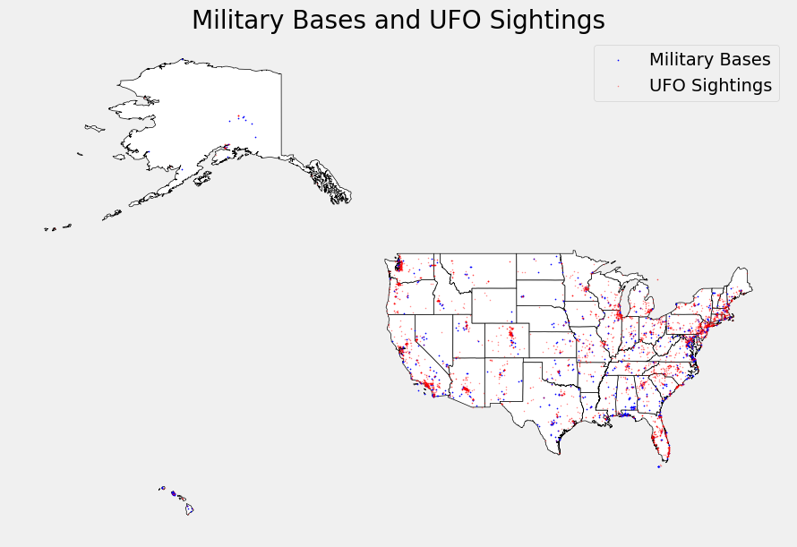

```python
base = state_map.plot(color="white", edgecolor="black", figsize=(10, 10))

ax = military_bases_gdf.plot(ax = base, color = "blue", markersize = 0.5, label = "Military Bases")
ax = ufo_sightings_gdf.plot(ax = base, color = "red", markersize = 0.5, alpha = 0.3, label = "UFO Sightings")

plt.legend();
plt.title("Military Bases and UFO Sightings");

ax.set_axis_off();
```

Here I have created red dots to represent UFO sightings and blue dots to represent military bases. I know this map is hard to read because of how small the dots are but I think it is the best way to represent the comparison I am tryong to make with locations. Just from looking at this map I cannot rule out that there isn't a trend. This is really exciting because I am curious to know what a hypothesis test has to say about the visual I created here.

## 3. Analyses

### Hypothesis Test

$H_0: p = 0.5$

The probability that UFO sightings occur within 10 miles of a military base at random chance is 50%.

$H_A: p > 0.5$

The probability of UFO sightings occurring within 10 miles of a military base is greater than 50%

```python
ufo_sightings_gdf = ufo_sightings_gdf.set_crs("EPSG:4326", allow_override = True)

# created a 10-mile buffer around each military base
military_bases_gdf["buffer"] = military_bases_gdf["geometry"].apply(
    lambda x: x.buffer(16093.4) if x.is_valid else None
)

buffer_gdf = gpd.GeoDataFrame(geometry = military_bases_gdf["buffer"], crs = military_bases_gdf.crs)

# joined buffer with sightings and removed any possible duplicates
ufo_within_buffer = gpd.sjoin(
    ufo_sightings_gdf, buffer_gdf, how = "inner", predicate = "within"
)

ufo_within_buffer = ufo_within_buffer.drop_duplicates(subset=["geometry"])

ufo_within_count = len(ufo_within_buffer)
total_ufo_count = len(ufo_sightings_gdf)
proportion_within = ufo_within_count / total_ufo_count

print("UFO sightings within 10 miles of military bases:", ufo_within_count)
print("Total UFO sightings:", total_ufo_count)
print("Proportion of sightings within 10 miles:", proportion_within)
```

```
UFO sightings within 10 miles of military bases: 2145
Total UFO sightings: 3396
Proportion of sightings within 10 miles: 0.6316254416961131
```

```python
def generate_proportion(n, heads_probability):
    rand_nums = np.random.rand(n)
    num_heads = np.sum(rand_nums <= heads_probability)
    return num_heads / n

generate_proportion(3396, 0.5)

example_proportion = generate_proportion(3396, 0.5)
example_proportion
```

```
0.49734982332155475
```

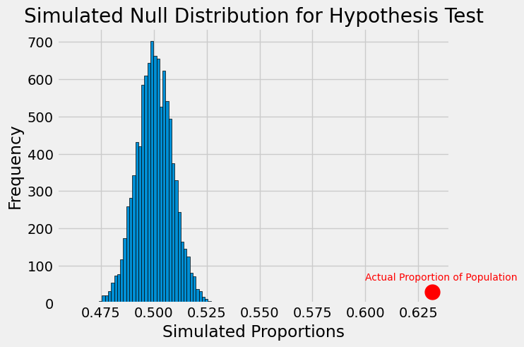

```python
null_dist = []

for i in range(10000):

    simulated_null_stat = generate_proportion(3396, 0.5)
    null_dist.append(simulated_null_stat)

plt.hist(null_dist, edgecolor = "black", bins = 50);

plt.title("Simulated Null Distribution for Hypothesis Test")
plt.xlabel("Simulated Proportions")
plt.ylabel("Frequency")

plt.plot(proportion_within, 30, '.', markersize = 30, color = "red");

plt.text(0.6, 60, "Actual Proportion of Population", fontsize = 10, color = "red");
```

```python
p_value = np.mean(np.array(null_dist) >= proportion_within)

p_value

print("p-value:", p_value)
```

```
p-value: 0.0
```

Since the p-value (0.0) is less than alpha (0.05) I reject the null hypothesis. The probability of seeing UFOs near military bases is not just due to random chance.

In order to use this type of analysis you must be looking at the full population of UFO sightings. I have decided that this data is representative of all of the sightings that the government has for the US because all I removed were points without any actual locations attached as well as data from other countries, but other than that I used all the thousands of points. If I would have just picked maybe 300 data points at random, then I would have used a different type of hypothesis test.

## 4. Conclusions

After comparing my data sets it is fair to say that I have found a clear link between UFO sightings and the distance someone is to a military base. I found this very insightful because I grew up with a father in the Marine Corps and have only lived in areas near military bases so I just assumed that seeing UFOs was a common thing for people. This project has given me a wider view on how simply living near military bases can affect someone's understanding of what is normal. This makes me even more curious to explore the effects of living near military bases on peoples' lives. I found a 2013 article from The National Library of Medicine titled "Exploring the Association Between Military Base Neighborhood Characteristics and Soldiers' and Airmen's Outcomes". This article only talks about the airmen themselves though so I think it would be really fun to explore this topic further.

Regarding future directions I can take with my data, I would really like to create an interactive map of the United States where you can click on each state and not only view the military bases, but the branch of each base. It would be a lot easier to see the correlations and it might clarify a thing or two about what branches are more involved with aviation (obviously airforce but I would like to know if there is a close second or if this data disproves my assumption). I would also like to map out the bases with their area, not just a point. I have the proper data to do that but I couldn't figure out how to so I just chose not to include that in my project.

I would love to conclude this paper by saying that UFO sightings are just new military technology that we don't know about yet but that is obviously not the case. My data shows that UFO sightings are way more common near military bases but there is no concluding factor of what causes this. I could also say that UFOs are extraterrestrial and that their landing pads just happen to be at military bases where they can conduct universal diplomacy easier, but my data doesn't prove that either. All I can say for sure is that there is a strong correlation between UFOs and their distance spotted within 10 miles of a military base. In the future, I hope to be able to answer all of my burning questions, but for now I am glad to have gained a bit of insight through YDATA 123.

## 6. Appendix

Below I included steps I printed out when working with GeoPandas. I also included the separate GeoPandas Mapping of military bases and UFO sightings in the United States.

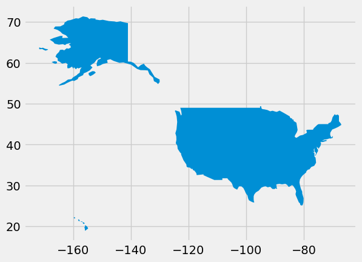

```python
import geopandas as gpd
import warnings

warnings.simplefilter(action='ignore', category=FutureWarning)

world = gpd.read_file(gpd.datasets.get_path('naturalearth_lowres'))

states_map = world.query("name == 'United States of America'")

states_map.plot();
```

```python
# originally I included this code to figure out which point was incorrectly labeled but
# I ended up fixing it and this line of code no longer works. I thought it would be helpful to just mention that I did this.

military_bases_gdf = gpd.GeoDataFrame(military_bases, geometry = "geometry")

military_bases_gdf[military_bases_gdf['longitude'] > 150]
```

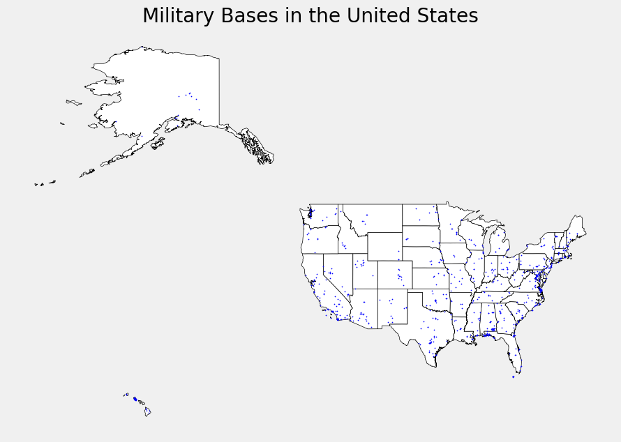

```python
state_map = gpd.read_file("States_shapefile.geojson")

base = state_map.plot(color = "white", edgecolor = "black", figsize=(10, 10))

ax = military_bases_gdf.plot(ax = base, color = "blue", markersize = .5);

ax.set_axis_off();

plt.title("Military Bases in the United States");
```

[output not shown]

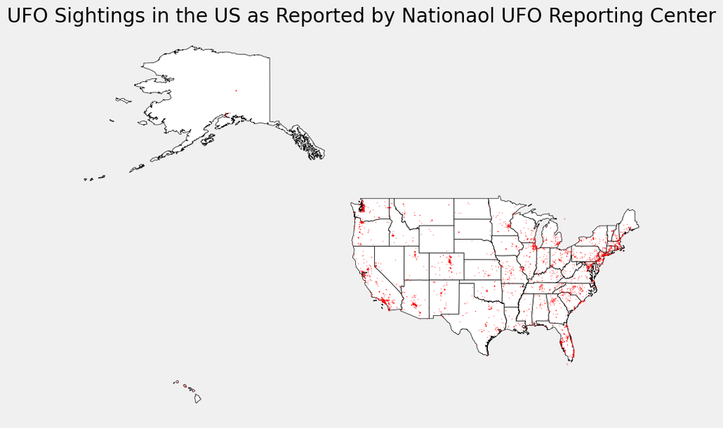

```python
import YData

YData.download.download_data("States_shapefile.geojson")

ufo_sightings["geometry"] = gpd.points_from_xy(ufo_sightings["Longitude"], ufo_sightings["Latitude"])

ufo_sightings_gdf = gpd.GeoDataFrame(ufo_sightings, geometry = "geometry")

ufo_sightings_gdf.set_crs("EPSG:4326", inplace = True)

base = state_map.plot(color = "white", edgecolor = "black", figsize=(10, 10))

ax = ufo_sightings_gdf.plot(ax = base, color = "red", markersize = .5, alpha = 0.3);

ax.set_axis_off();

import matplotlib.pyplot as plt

plt.title("UFO Sightings in the US as Reported by Nationaol UFO Reporting Center");
```

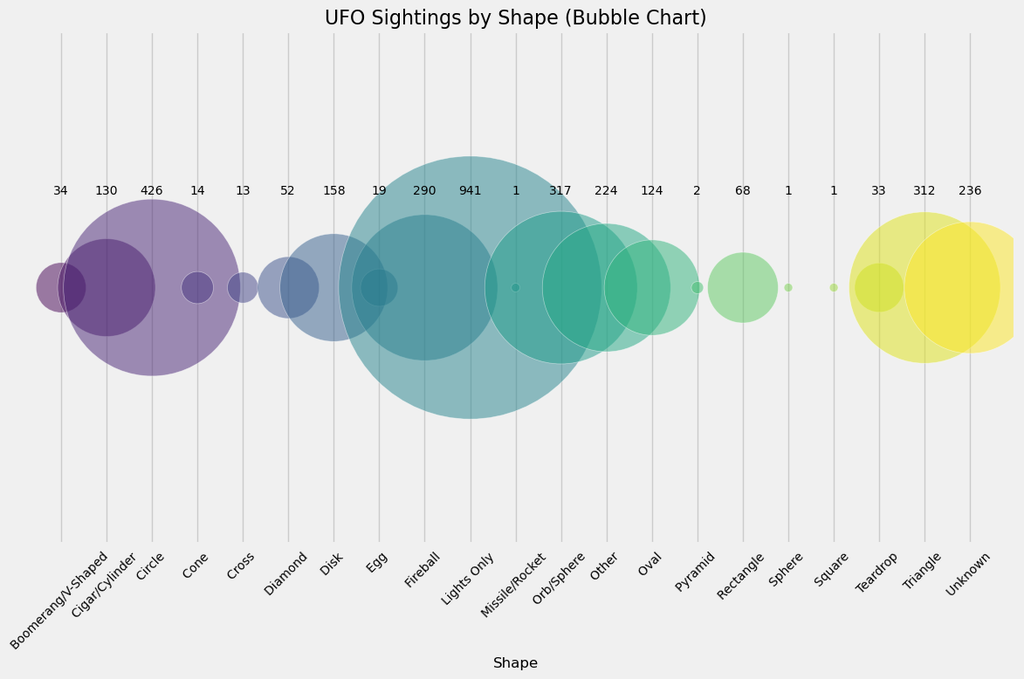

```python
sightings_by_shape = ufo_sightings.groupby("Shape").size().reset_index(name = "Count")

fig, ax = plt.subplots(figsize=(12, 8))
bubble = ax.scatter(
    x = sightings_by_shape["Shape"],
    y = [1] * len(sightings_by_shape),
    s = sightings_by_shape["Count"] * 50,
    alpha = 0.5,
    c = range(len(sightings_by_shape)),
    cmap = "viridis",
    edgecolors = "white",
)

for i, row in sightings_by_shape.iterrows():
    ax.text(
        row["Shape"],
        1.02,
        row["Count"],
        ha = "center",
        fontsize = 10,
        color="black"
    )

ax.set_title("UFO Sightings by Shape (Bubble Chart)", fontsize = 16)
ax.set_ylabel("")
ax.get_yaxis().set_visible(False)
ax.set_xlabel("Shape", fontsize = 12)
plt.xticks(rotation = 45, fontsize = 10)

plt.tight_layout()
plt.show()
```

I wanted to show the different types of shapes of UFO sightings just because I thought it would be fun to see what is most commonly reported. I think it also helps set an understanding of what people are seeing and if I had more time I think it would be interesting to see which shapes are most commonly seen in which locations and whether any of the shapes have any sort of alignment with the military bases as well. I chose to use a bubble chart just to use a new type of graph that is more fun to look at and kind of reminded me of UFOs.

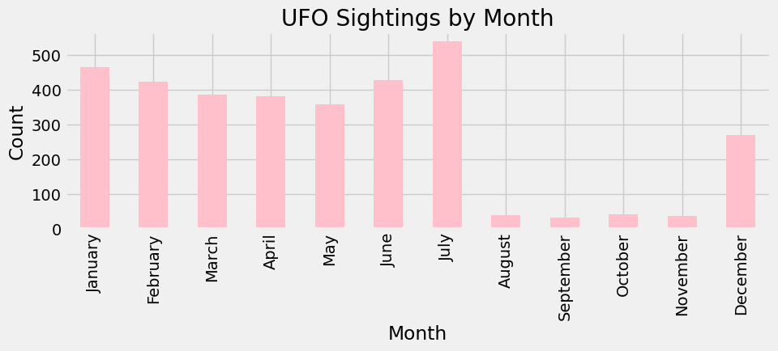

```python
import calendar

ufo_sightings["Event.Date"] = pd.to_datetime(ufo_sightings["Event.Date"], errors="coerce")

ufo_sightings["Month"] = ufo_sightings["Event.Date"].dt.month
ufo_sightings["Month Name"] = ufo_sightings["Event.Date"].dt.month_name()

sightings_by_month = ufo_sightings.groupby("Month Name").size()

sightings_by_month = sightings_by_month.reindex(calendar.month_name[1:])

sightings_by_month.plot(
    kind = "bar",
    figsize = (10, 3),
    title = "UFO Sightings by Month",
    xlabel = "Month", ylabel = "Count",
    color = "pink"
);
```

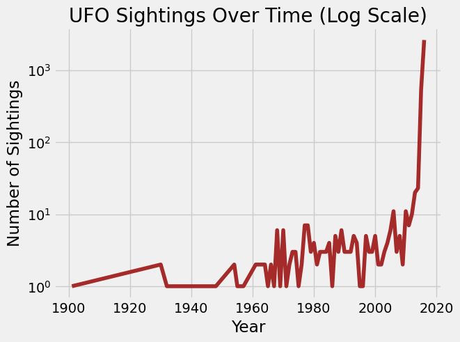

```python
ufo_sightings["Event.Date"] = pd.to_datetime(ufo_sightings["Event.Date"])
ufo_sightings["Year"] = ufo_sightings["Event.Date"].dt.year

sightings_by_year = ufo_sightings.groupby("Year").size()

plt.style.use("fivethirtyeight")

sightings_by_year.plot(
    kind = "line",
    title = "UFO Sightings Over Time (Log Scale)",
    logy = True,
    xlabel = "Year",
    ylabel = "Number of Sightings",
    color = "brown"
)
plt.show()
```

I decided to include this chart to show that most data points are more recent. This change can be due to better technology that allows us to capture these UFOs or it can be that more of a focus has been put into understanding and identifying UFOs. This is something I find really interesting and it sparked my idea to explore its relation to military bases. It made me curious if this had anything to do with the 2016 election and the later 2019 creation of the Space Force.

### Project Reviews

#### Project writer name: Isabel Nuno

#### Project writer email address: isabel.nuno@yale.edu

#### Reviewer name: Josie Russell

#### Reviwer email address: josie.russell@yale.edu

#### Summary

This project sought to investigate whether there tends to be more UFO sightings near military bases than away from them. There is a pause to investigate and view shapes of UFO sightings, and then a few maps of the US depicting the locations of UFO sightings and military bases, both by state and in general. These latter maps show that there is a possibility of more UFO sightings being near military bases, so a hypothesis test is used to determine if these sightings likely occur by chance or not. The null hypothesis is then rejected, suggesting that there is a relationship between UFO sightings and military bases that is not only left to chance.

#### 1. Overall strengths and weaknesses

I think that overall, this is a really strong project period. Your graphs are beautiful and relatively easy to read, and they lend themselves to explaining why you proceeded to run a hypothesis test. For the most part, there was also a consistent line of logic in your project that (satisfyingly) led to a rejection of your null hypothesis. I think that I learned a lot here!

Some things that I would suggest are just to make the transitions between steps more fluid, and explain what you're doing initially so that the reader doesn't have to guess. Additionally, the UFO shape section seems a little out of place, and the project goes over the 10 page limit (which is an easy fix). Still, this project was intruiging and well-executed.

#### 2. Major revisions

- Not HUGE but something: your visualizations come a little abruptly sometimes. Especially with the third figure under the Geopandas section, I think including a subtitle or a line of writing just explaining what you're visualizing before hand will help orient the reader.
- In your appendix, I think that it would be helpful to label each of the graphs included or tell where they came from in your code above so that it's easier to place them within your project.
- The biggest issue here is just that your conclusion and reflection trickle onto page 12; I think that almost all of what you note is really interesting, though, so I would suggest moving more of your code from above to the appendix in order to meet the page limit.
- For the UFO Sightings by Shape chart, I think I'm a little confused as to why it was included. Maybe include a few sentences about why shapes of UFOs is important to view when considering your larger question of sightings and military bases.

#### Rubric items where points would be taken off if not addressed:

• Plots do not add any insight into the question of interest

• Code is not neat or well commented

#### Total score: 86/90

#### Project writer name: Isabel Nuno

#### Project writer email address: isabel.nuno@yale.edu

#### Reviewer name: Kristian Odobashi

#### Reviwer email address: kristian.odobashi@yale.edu

#### Summary

This project aimed to explore whether there is a correlation between UFO sightings and proximity to United States military bases, which could provide insight into what people are really seeing when they claim to sight a UFO. The project creates visualizations of data - such as the shapes of UFO sightings, and others in the appendix - which may not be totally connected to the research questions but are still interesting to see, as well as the locations of military bases and UFO sightings on a map of the United States. Then, a hypothesis test of proportions is done on the probability that a UFO sighting occurs within 10 miles of a military base; the test uses a null hypothesis of random chance 50% of this occuring and an alternative hypothesis of greater than 50% chance. The conclusion is a strong correlation (with a p-value of 0.0), but no proof of causation.

#### 1. Overall strengths and weaknesses

I thought that your topic was very interesting and that your results could be used to understand why certain areas in the US have far greater UFO sightings than others, and what these UFOs actually are. Your visualizations were well-made and mostly had a clear aim in answering your research question, but I felt that your visualization of the UFO shapes could have been used more, possibly through some sort of K-Nearest Neighbors algorithm for considering UFO shape (or the time of the year data). However, this isn't necessary for your project's goal and could take up too much space - I just think it would be an interesting analysis. The hypothesis test was convincing, and though I appreciate your defence for using a hypothesis test, I didn't think that it was necessary; in other words, I was convinced there was a correlation even without your defence.

#### 2. Major revisions

• Make sure that code is not cut off for the final submission • Describe some aspects of the data wrangling done on the csv file or show it in the appendix, although I'm not sure if this is actually necessary

#### 3. Minor revisions

• Project length could be cut down to stay under ten pages (not including reflection/ appendix) • The graph with military bases and UFO sightings on the US map could have larger, easier to see points • Labels for the hypothesis test graph and, if possible, the bubble chart • More comments on some of the code would be useful, even if little, to explain what is being done • Minor typos

#### 3. Rubric score

• Did not show data wrangling, or describe that the data was already clean (Unsure - took no points off for this) • Code is not neat or well commented (Data running off and maybe some more comments needed) • Visual appearance of graphs could be improved (i.e., missing labels)

#### Total score: 86/90

#### Project Writer Name: Isabel Nuno

#### Project Writer Email Address: isabel.nuno@yale.edu

#### Reviewer Name: Roan Hollander

#### Reviewer Email Address: roan.hollander@yale.edu

#### Summary

This project uses United States UFO sighting data to see where UFO sightings commonly occur and looks at other trends in the data. First, it looks at what shapes/types of UFOs are most commonly reported. It then compares what states have the most active military bases and where the most UFO sightings are reported, then plots where UFO sightings were recorded and where military bases are. It conducts an analysis to see if there is a correlation between short distance from a military base and frequent UFO sightings, finding that the number of UFOs seen near a military base is not random chance.

#### 1. Overall Strengths and Weaknesses

I really thought that the combination of graphs, maps, and the hypothesis test done was well-balanced! Everything was very clear to interpret and the connection between military bases and UFOs was so interesting. There were very thorough explanations of everything being displayed, which made the findings very apparent and easy to digest. The hypothesis test was also very well done and clearly showed a connection between proximity to military bases and prevalence of UFO sightings.

For things to improve, I think comparing the heatmaps side by side but not next to each other might make them bigger and easier to read (if this is possible to do). I really like the bubble chart but I think it's not the clearest to interpret, so maybe it could benefit from additional manipulation or a different display. I think the map showing military bases and UFO sightings looks great, but maybe colors that are more distinctive from each other would make the correlation show up a bit clearer.

#### 2. Major Revisions

• Changing heatmap orientation • Making the bubble chart clearer to understand

#### 3. Minor Revisions

• Changing colors in the map showing plotted military bases and UFO sightings

#### 3. Rubric Score

Rubric Items Where Points Would Be Taken Off If Not Addressed: • Visual appearance of graphs could be improved; e.g., missing labels, poor color choices, etc.

#### Score: 88/90